# Using python + R with Reticulate

Seung Hyun Sung

2022-10-23

#### Purpose

The most popular data science languages are Python and R. Data scientists that learn to use the strengths of both languages are becoming credentials. Understanding the strengths and weaknesses of these languages and by shaping our data science workflow will make us work productively.

- **EDA**, **Visualisation**, **Apps & Reporting**: Switch to R to use tidyverse, shiny and rmarkdown
- **Machine Learning**: Switch to Python to leverage scikit learn and tensorflow

#### Reticulate Setup

The **reticulate** package lets you use Python and R together seamlessly in R code, in R Markdown documents, and in the RStudio IDE, and thus with HUGO blogdown here to upload on the webpage.

- Package gets updated reguarly - lock down
- 프로젝트별 특정 패키지 특정 환경 - 가상환경 구축이 필요함 - miniconda 유용함
1. Creating a new Virtual Environment

The following command takes ‘-n’ as a flag, which is for creating new environment with its name as ‘env’ and the specific Python version of ‘3.7’. `conda create -n env python = 3.7`

```r
library(tidyverse)
library(reticulate)
```

```r
reticulate::use_condaenv("r-reticulate", required = TRUE)
py_config()
```

```
## python:         C:/Users/sung9/AppData/Local/r-miniconda/envs/r-reticulate/python.exe
## libpython:      C:/Users/sung9/AppData/Local/r-miniconda/envs/r-reticulate/python37.dll
## pythonhome:     C:/Users/sung9/AppData/Local/r-miniconda/envs/r-reticulate
## version:        3.7.10 (default, Feb 26 2021, 13:06:18) [MSC v.1916 64 bit (AMD64)]
## Architecture:   64bit
## numpy:          C:/Users/sung9/AppData/Local/r-miniconda/envs/r-reticulate/Lib/site-packages/numpy
## numpy_version:  1.19.5
##
## NOTE: Python version was forced by RETICULATE_PYTHON
```

#### Conda Installation

```python
import numpy as np
import pandas as pd
import matplotlib.pyplot as plt
```

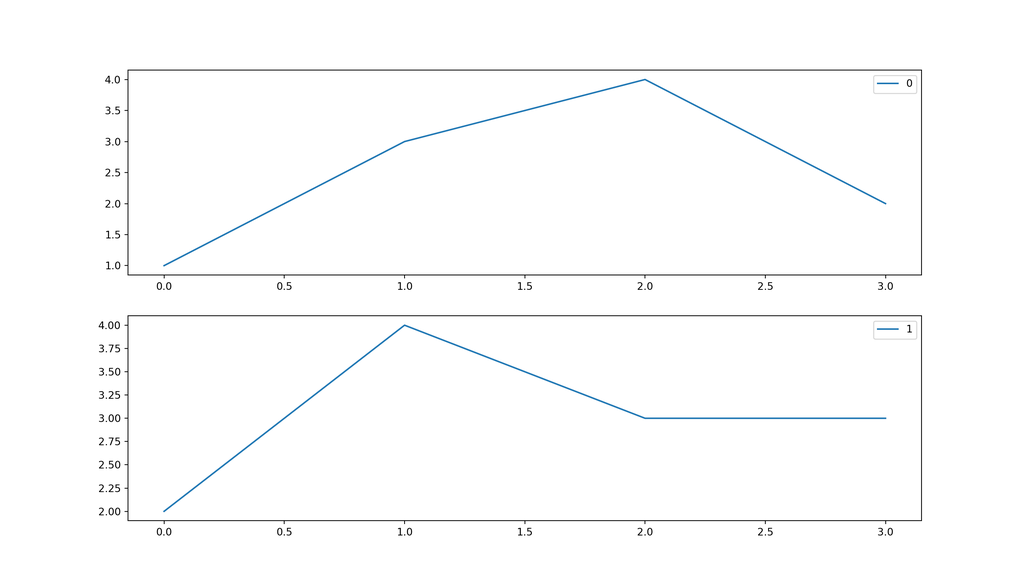

```python
df=pd.DataFrame([[1, 2], [3, 4], [4, 3], [2, 3]])
fig = plt.figure(figsize=(14,8))
for i in df.columns:
    ax=plt.subplot(2,1,i+1)
    df[[i]].plot(ax=ax)
    print(i)

plt.show()
```

```python
from sklearn.ensemble import RandomForestClassifier
clf = RandomForestClassifier(random_state=0)

X = [[ 1,  2,  3],  # 2 samples, 3 features
     [11, 12, 13]]

y = [0, 1]  # classes of each sample

clf.fit(X, y)
```

```
## RandomForestClassifier(random_state=0)
```

```python
clf.predict(X)
```

```
## array([0, 1])
```

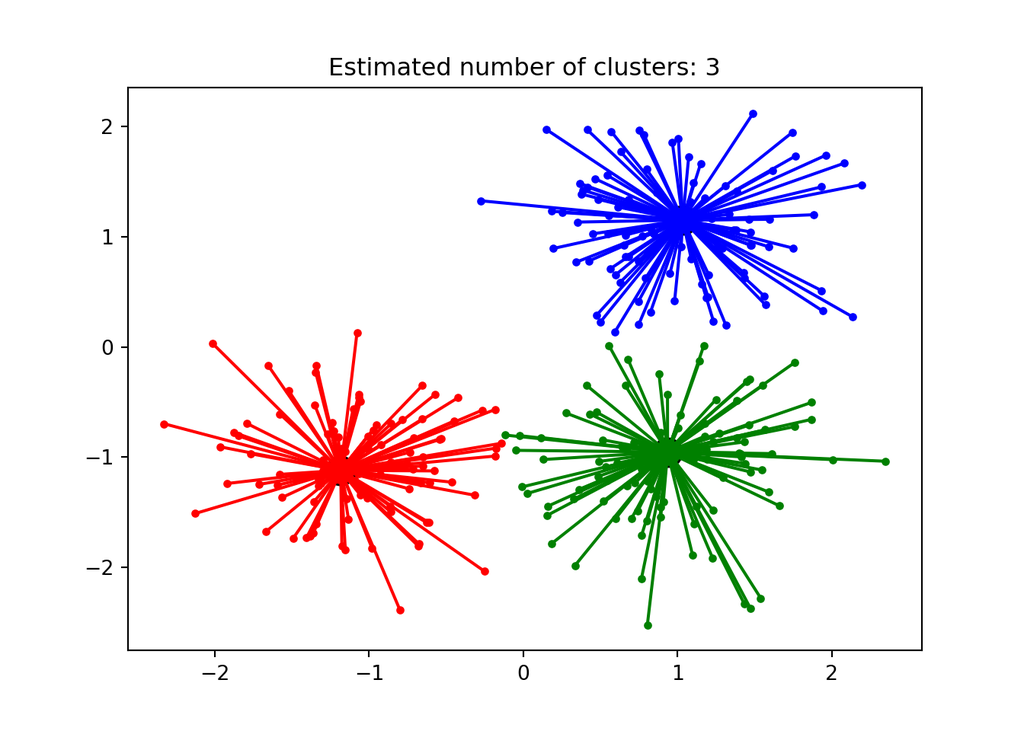

```python
from sklearn.cluster import AffinityPropagation
from sklearn.datasets import make_blobs

# #############################################################################
# Generate sample data
centers = [[1, 1], [-1, -1], [1, -1]]
X, labels_true = make_blobs(n_samples=300, centers=centers, cluster_std=0.5,
                            random_state=0)

# Compute Affinity Propagation
af = AffinityPropagation(preference=-50).fit(X)
cluster_centers_indices = af.cluster_centers_indices_
labels = af.labels_

n_clusters_ = len(cluster_centers_indices)

# #############################################################################
# Plot result
import matplotlib.pyplot as plt
from itertools import cycle

plt.close('all')
plt.figure(1)
plt.clf()

colors = cycle('bgrcmykbgrcmykbgrcmykbgrcmyk')
for k, col in zip(range(n_clusters_), colors):
    class_members = labels == k
    cluster_center = X[cluster_centers_indices[k]]
    plt.plot(X[class_members, 0], X[class_members, 1], col + '.')
    plt.plot(cluster_center[0], cluster_center[1], 'o', markerfacecolor=col,
             markeredgecolor='k', markersize=14)
    for x in X[class_members]:
        plt.plot([cluster_center[0], x[0]], [cluster_center[1], x[1]], col)

plt.title('Estimated number of clusters: %d' % n_clusters_)
plt.show()
```